# R for Data Science

### 1.5.1 Two Categorical Variables

범주현 변수들 사이에 공분산을 시각화하기 위해, 각 조합에 대한 관측치의 수를 세린다.

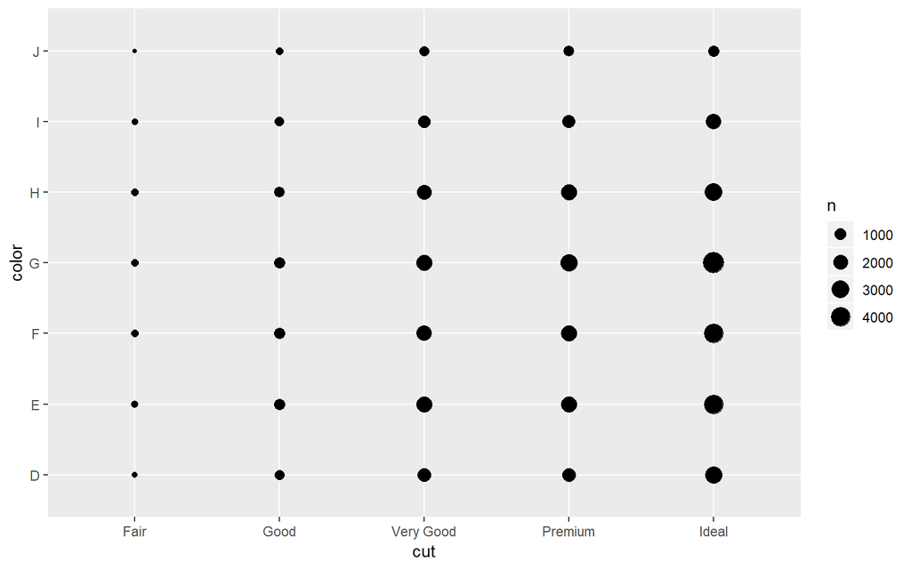

```r
ggplot(diamonds) +
  geom_count(aes(cut, color))
```

```r
diamonds %>%
  count(color, cut)
```

```
## # A tibble: 35 x 3
##    color cut           n
##    <ord> <ord>     <int>
##  1 D     Fair        163
##  2 D     Good        662
##  3 D     Very Good  1513
##  4 D     Premium    1603
##  5 D     Ideal      2834
##  6 E     Fair        224
##  7 E     Good        933
##  8 E     Very Good  2400
##  9 E     Premium    2337
## 10 E     Ideal      3903
## # ... with 25 more rows
```

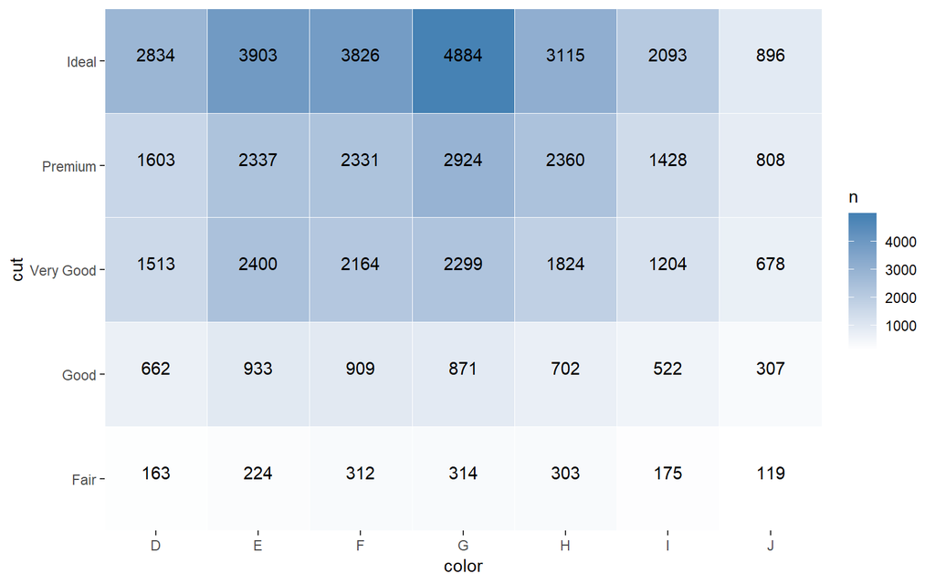

```r
diamonds %>%
  count(color, cut) %>%
  ggplot(aes(color, cut)) +
    geom_tile(aes(fill = n), colour = "white") +
    geom_text(aes(label = n), vjust = "bottom") +
    scale_fill_gradient(low = "white", high = "steelblue") +
    scale_x_discrete(expand = c(0, 0)) +
    scale_y_discrete(expand = c(0, 0))
```

```r
library(d3heatmap)
data.matrix(mtcars) %>%  # 모든 변수를 수치형으로
d3heatmap(scale = "column", colors = "Blues",Rowv = FALSE, Colv = FALSE)
```

[interactive chart not shown]

```r
d3heatmap(mtcars, scale = "column", colors = "Spectral")
```

[interactive chart not shown]

## 1.6 Exercises

1. How could you rescale the count dataset to more clearly show the distribution of cut within color, or color within cut?

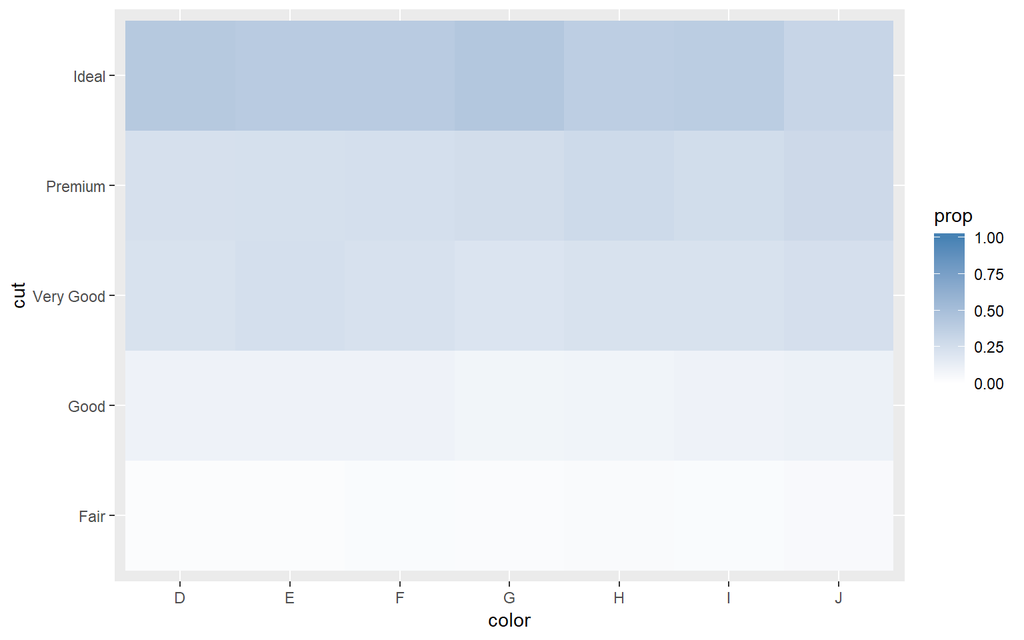

```r
diamonds %>%
  count(color, cut) %>%
  group_by(color) %>%
    mutate(prop = n / sum(n)) %>%
  ggplot(aes(color, cut)) +
    geom_tile(aes(fill = prop)) +
    scale_fill_gradient(low = "white", high = "steelblue", limits = c(0, 1))
```

2. Use geom_tile() together with dplyr to explore how average flight delays vary by destination and month of year. What makes the plot difficult to read? How could you improve it?

*fct_reorder*

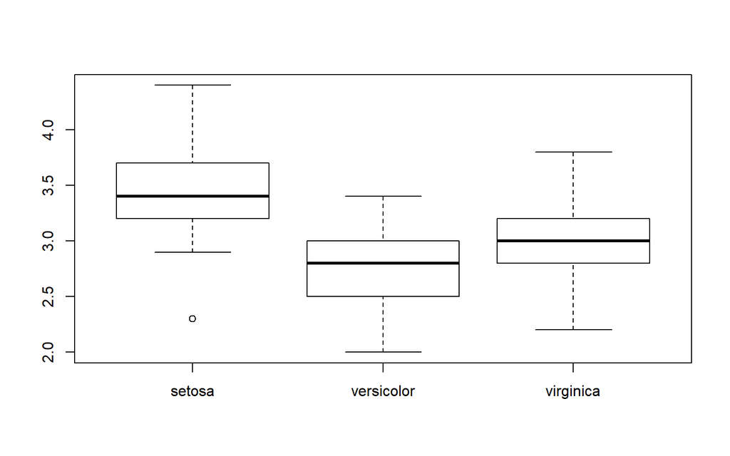

```r
boxplot(Sepal.Width ~ Species, data = iris)
```

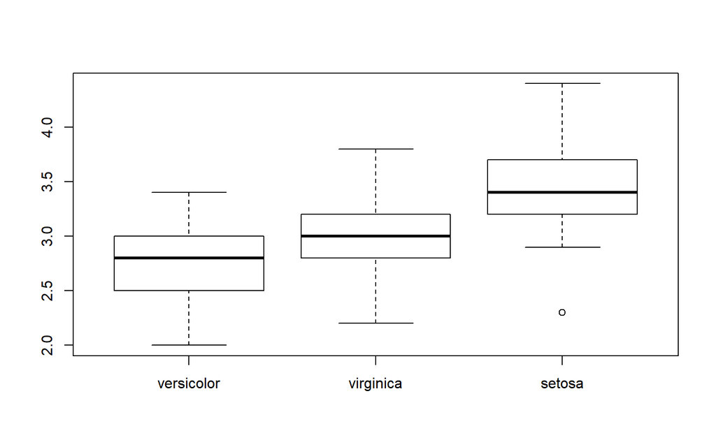

```r
boxplot(Sepal.Width ~ fct_reorder(Species, Sepal.Width), data = iris)
```

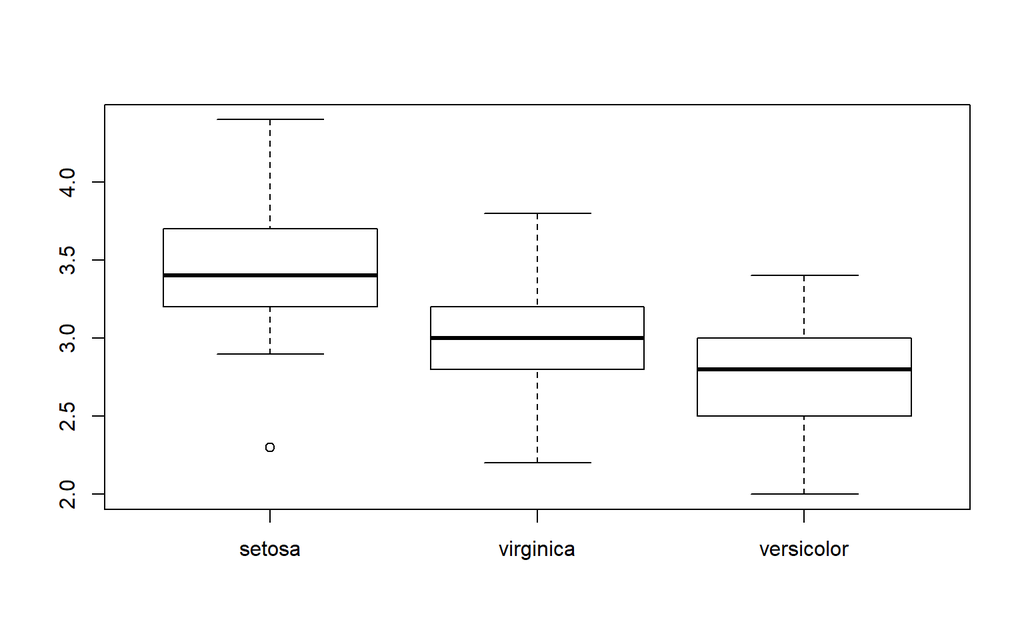

```r
boxplot(Sepal.Width ~ fct_reorder(Species, Sepal.Width, .desc = TRUE), data = iris)
```

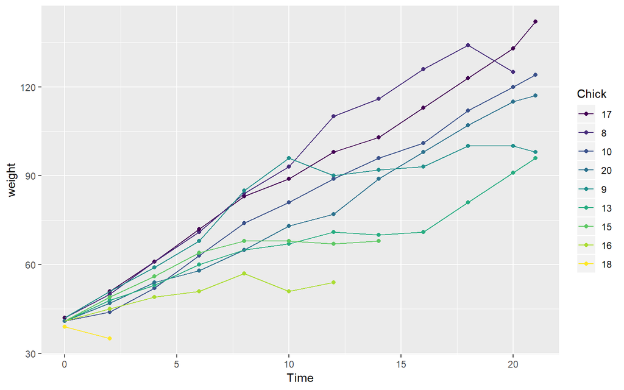

```r
chks <- subset(ChickWeight, as.integer(Chick) < 10)
chks <- transform(chks, Chick = fct_shuffle(Chick))

if (require("ggplot2")) {
  ggplot(chks, aes(Time, weight, colour = Chick)) +
    geom_point() +
    geom_line()

  # Note that lines match order in legend
  ggplot(chks, aes(Time, weight, colour = fct_reorder2(Chick, Time, weight))) +
    geom_point() +
    geom_line() +
    labs(colour = "Chick")
}
```

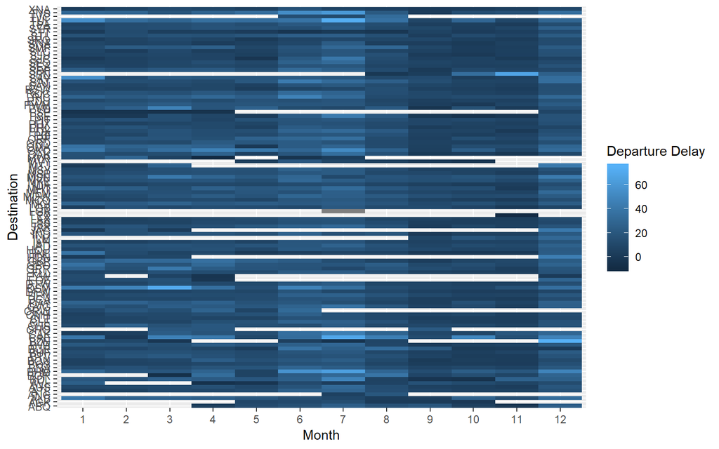

```r
library(forcats)
flights %>%
  group_by(month, dest) %>%
  summarise(dep_delay = mean(dep_delay, na.rm = TRUE)) %>%
  ggplot(aes(x = factor(month), y = dest, fill = dep_delay)) +
  geom_tile() +
  labs(x = "Month", y = "Destination", fill = "Departure Delay")
```

개선시킬 몇가지가 있다.

- 의미 있는 양(distance, number of flights, average delay)로 목적지를 정렬한다.
- 결측치를 제거한다.
- 더 좋은 색상을 사용(viridis)

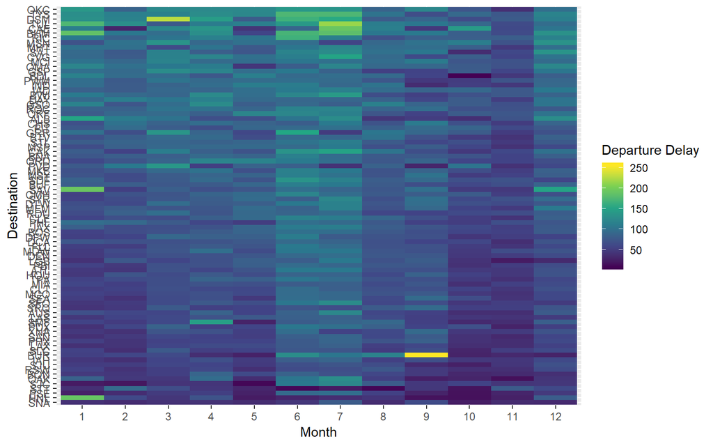

```r
flights %>%
  mutate(tot_delay = dep_delay + arr_delay) %>%
  filter(tot_delay > 0) %>%
  group_by(dest, month) %>%
  summarise(avg_tot_delay = mean(tot_delay, na.rm = TRUE)) %>%
  filter(n() == 12) %>% # 12달 전부 있어야하므로
  ungroup() %>%
  ggplot(aes(factor(month), fct_reorder(dest, avg_tot_delay))) + # reorder()은 FUN = mean이 디폴트이고 fct_reorder은 median이 디폴트
    geom_tile(aes(fill = avg_tot_delay)) +
    scale_fill_viridis_c() +
  labs(x = "Month", y = "Destination", fill = "Departure Delay")
```

여기서 `ungroup()`이 필요한 이유를 짚고 넘어가자.

```r
data.frame(Titanic) %>%
  group_by(Class, Age) %>%
  summarize(Freq = sum(Freq)) %>%
  mutate(Class = reorder(Class, Freq))
```

[output not shown]

```r
data.frame(Titanic) %>%
  group_by(Class, Age) %>%
  summarize(Freq = sum(Freq)) %>%
  ungroup() %>%
  mutate(Class = reorder(Class, Freq))
```

```
## # A tibble: 8 x 3
##   Class Age    Freq
##   <fct> <fct> <dbl>
## 1 1st   Child     6
## 2 1st   Adult   319
## 3 2nd   Child    24
## 4 2nd   Adult   261
## 5 3rd   Child    79
## 6 3rd   Adult   627
## 7 Crew  Child     0
## 8 Crew  Adult   885
```

1. 그룹화 때문에 일어나는 의도치 않은 잠재적 오류를 피한다.
2. str(df)했을 때, grouped_df 라고 안뜸
3. .Rdata 오브젝트를 저장하고 로드하는데 빠르다고 한다.

## 1.7 Two Continuous Variables

케럿과 가격의 지수적 관계를 볼 수 있다.

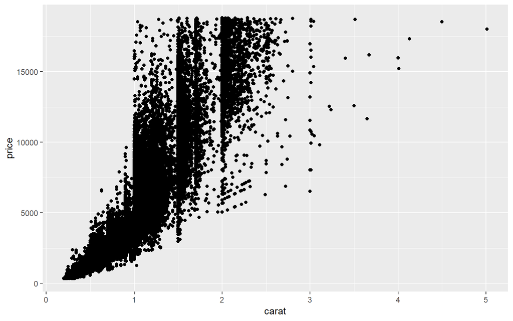

```r
ggplot(diamonds) +
  geom_point(aes(carat, price))
```

데이터셋이 커지면 오버플랏 때문에 산점도가 덜 유용해진다.

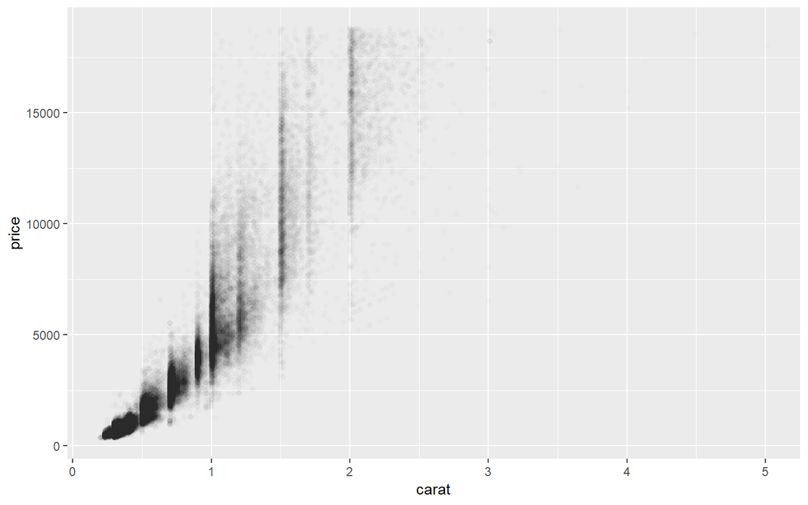

```r
ggplot(diamonds) +
  geom_point(aes(carat, price), alpha = 1/100)
```

하지만 굉장히 큰 데이터셋에는 투명도를 사용하는 것이 어렵다. 다른 방법은 bin을 사용하는 것이다.

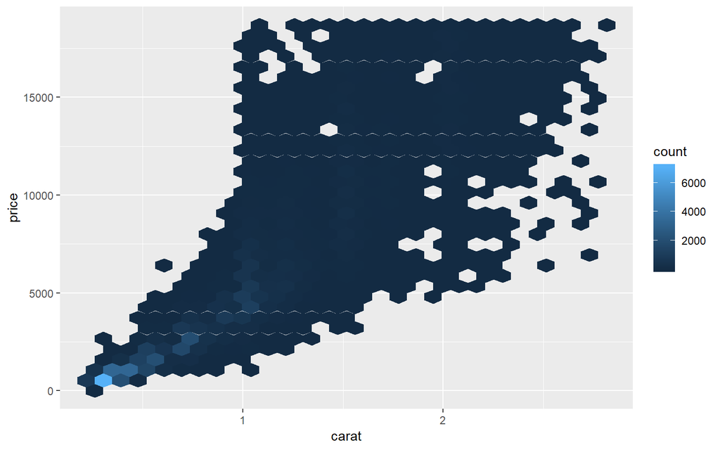

```r
ggplot(smaller) +
  geom_hex(aes(carat, price))
```

다른 방법은 연속형 변수를 범주형 변수처럼 bin하는 것이다.

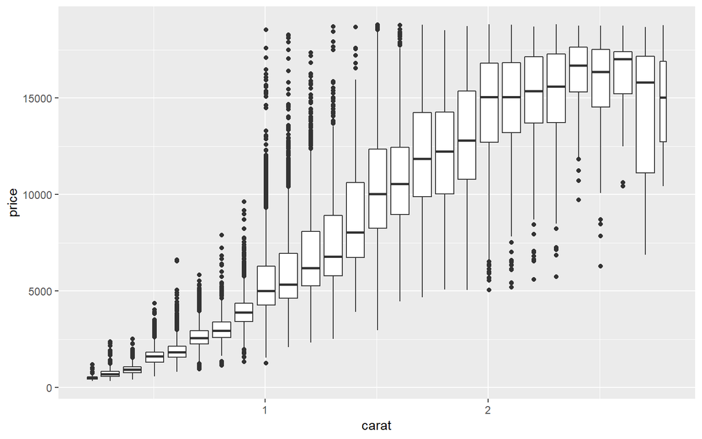

```r
ggplot(smaller, aes(carat, price)) +
  geom_boxplot(aes(group = cut_width(carat, 0.1)))
```

각각의 박스플랏이 다른 점의 수를 요약한다고 말하기는 어렵다. 따라서 `cut_number()`를 사용해 보자.

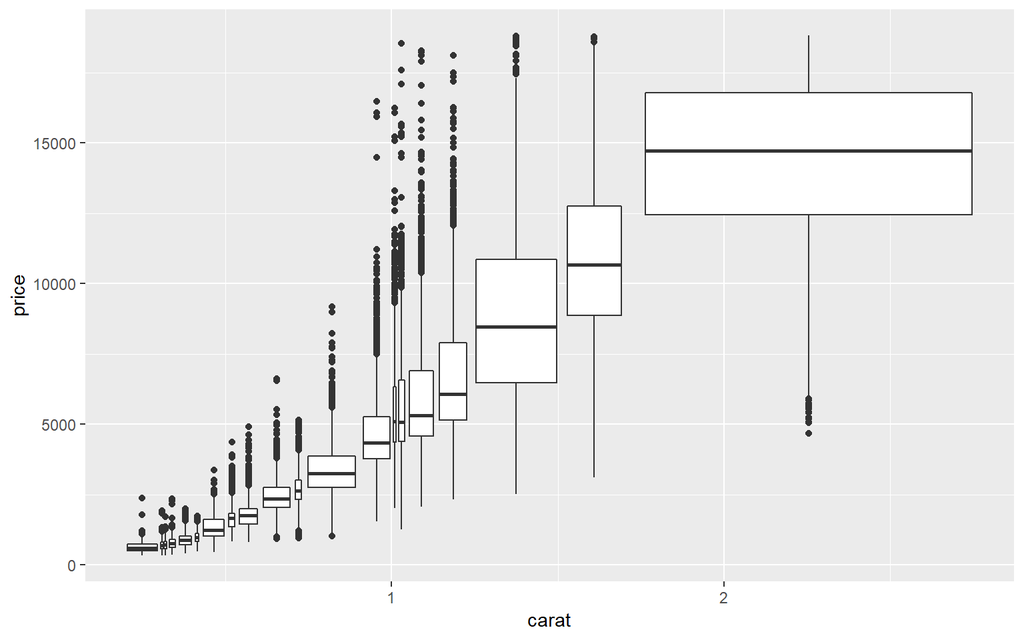

```r
ggplot(smaller, aes(carat, price)) +
  geom_boxplot(aes(group = cut_number(carat, 20)))
```

## 1.8 Exercises

1. Instead of summarizing the conditional distribution with a boxplot, you could use a frequency polygon. What do you need to consider when using cut_width() versus cut_number()? How does that impact a visualization of the 2D distribution of carat and price?

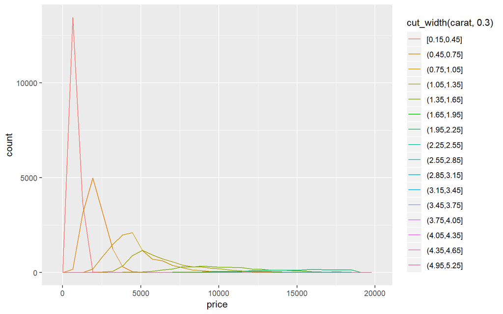

```r
ggplot(data = diamonds,
       mapping = aes(x = price,
                     colour = cut_width(carat, 0.3))) +
  geom_freqpoly()
```

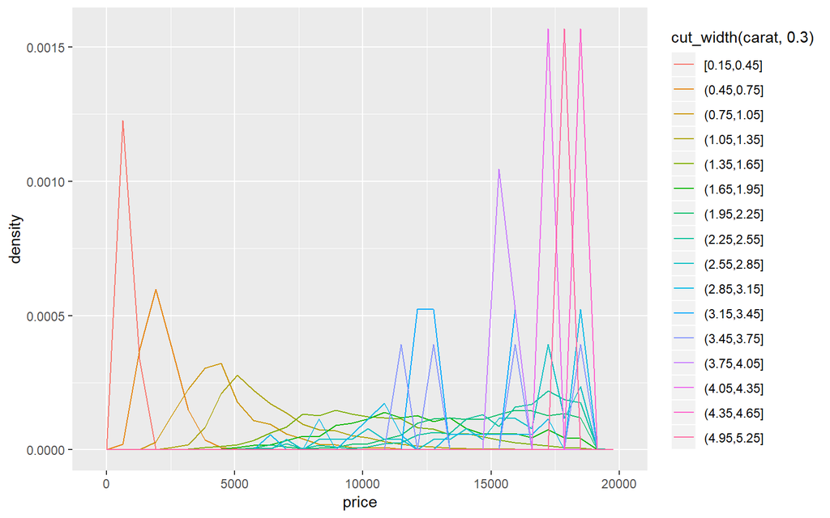

```r
# 해석이 어렵다.
ggplot(data = diamonds,
       mapping = aes(x = price,
                     y = ..density..,
                     colour = cut_width(carat, 0.3))) +
  geom_freqpoly()
```

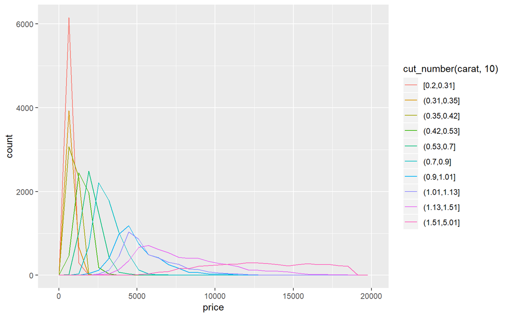

```r
ggplot(data = diamonds,
       mapping = aes(x = price,
                     colour = cut_number(carat, 10))) +
  geom_freqpoly()
```

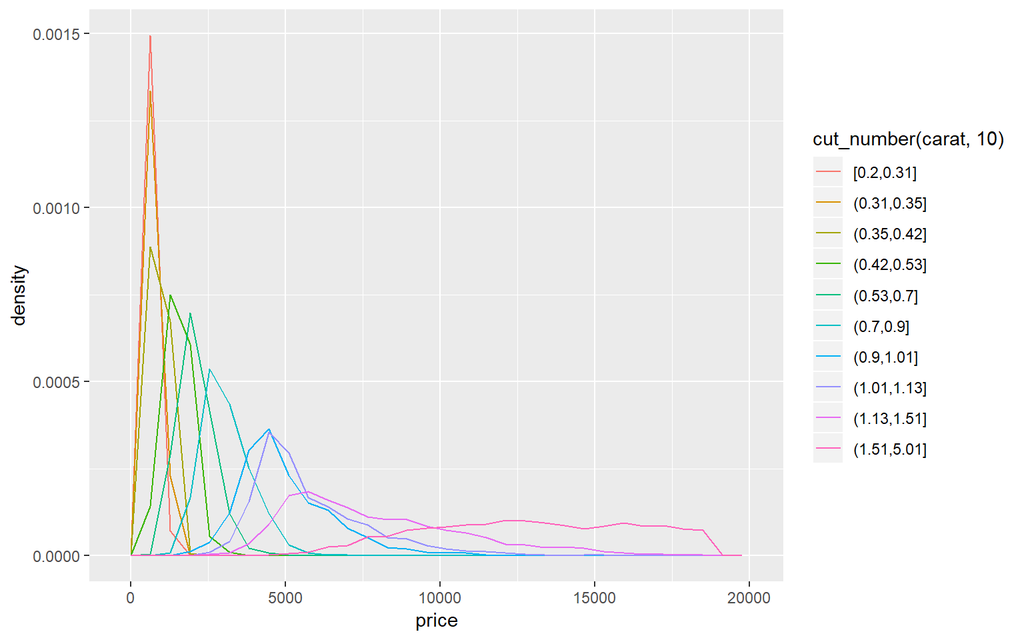

```r
ggplot(data = diamonds,
       mapping = aes(x = price,
                     y = ..density..,
                     colour = cut_number(carat, 10))) +
  geom_freqpoly()
```

케럿이 클 때는 가격의 분포가 넓게 분포되어 가격이 큰지 작은지를 따지기가 애매하다.

2. Visualize the distribution of carat, partitioned by price.

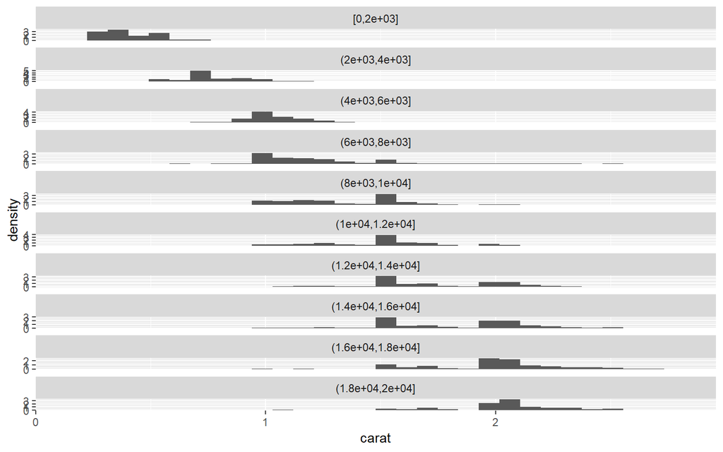

```r
smaller %>%
  mutate(cut_price = cut_width(price, 2000, boundary = 0)) %>%
  ggplot(aes(carat, ..density..)) +
    geom_histogram() +
    facet_wrap(~cut_price, ncol = 1, scales = "free_y") +
    theme(strip.text = element_text())
```

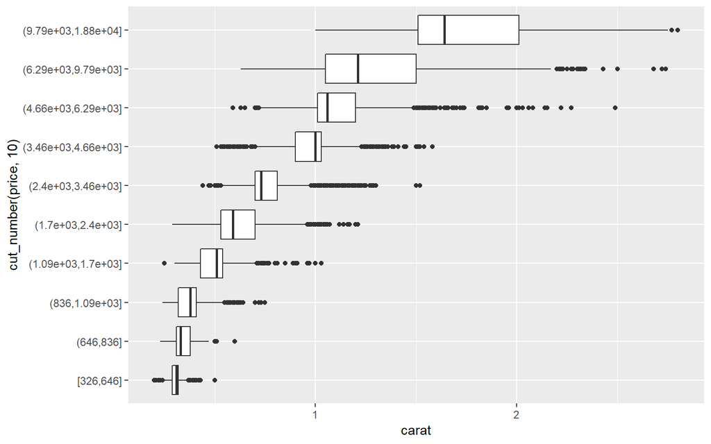

```r
ggplot(smaller, aes(cut_number(price, 10), carat)) +
  geom_boxplot() +
  coord_flip()
```

boundary 0을 설정하면 첫번째 구간이 0 ~ 2000임을 보장한다.

3. How does the price distribution of very large diamonds compare to small diamonds. Is it as you expect, or does it surprise you?

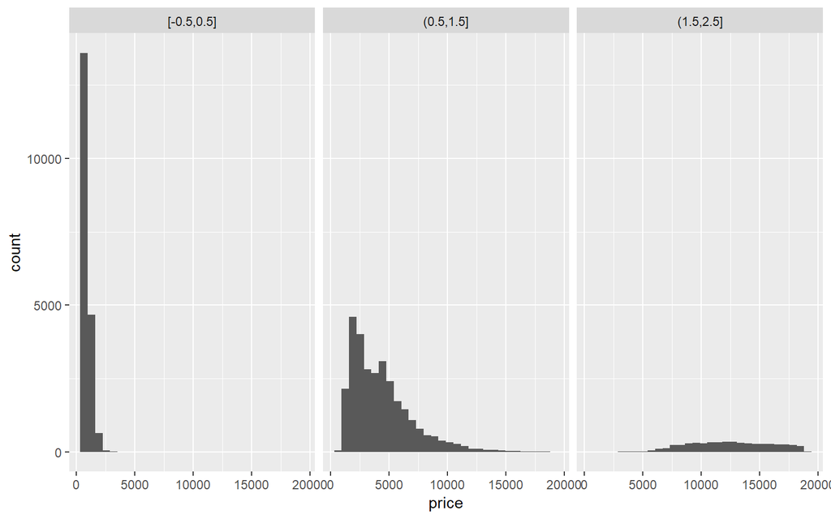

```r
diamonds %>%
  filter(between(carat, 0, 2.5)) %>%
  mutate(carat = cut_width(carat, 1)) %>%
  ggplot(aes(price)) +
           geom_histogram() +
           facet_wrap(~ carat) # mutate를 생랼하고 여기서 cut_width을 해도 된다.
```

케럿이 클수록 분산이 커진다는 것을 알 수 있다.

4. Combine two of the techniques you’ve learned to visualize the combined distribution of cut, carat, and price.

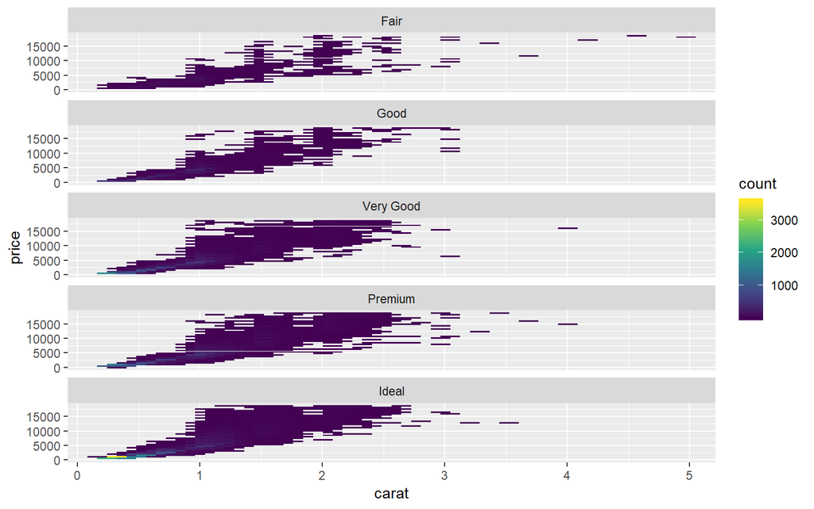

```r
ggplot(diamonds, aes(x = carat, y = price)) +
  geom_hex() +
  facet_wrap(~ cut, ncol = 1) +
  scale_fill_viridis_c()
```

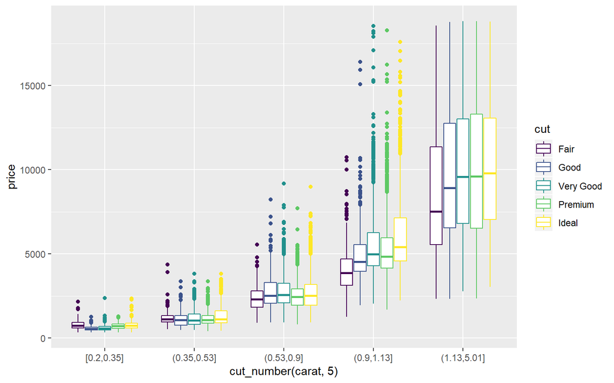

```r
ggplot(diamonds, aes(x = cut_number(carat, 5), y = price, colour = cut)) +
  geom_boxplot()
```

5. Two-dimensional plots reveal outliers that are not visible in one-dimensional plots. For example, some points in the following plot have an unusual combination of x and y values, which makes the points outliers even though their x and y values appear normal when examined separately:

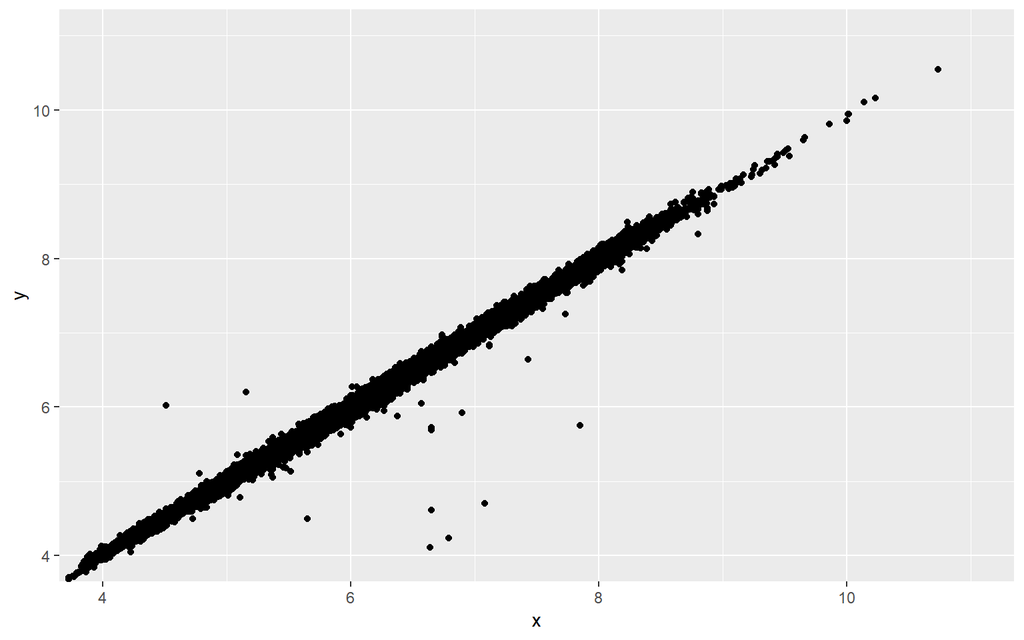

```r
ggplot(data = diamonds) +
  geom_point(mapping = aes(x = x, y = y)) +
  coord_cartesian(xlim = c(4, 11), ylim = c(4, 11))
```

Why is a scatterplot a better display than a binned plot for this case?

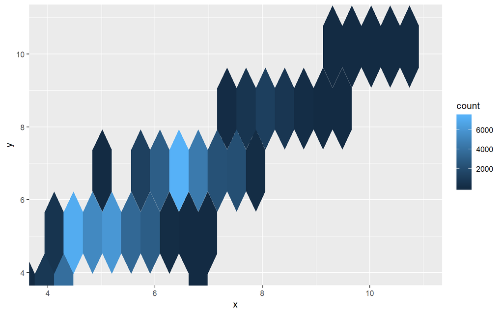

```r
ggplot(data = diamonds) +
  geom_hex(mapping = aes(x = x, y = y)) +
  coord_cartesian(xlim = c(4, 11), ylim = c(4, 11))
```

bin2d를 사용하면 이상치가 보이지 않으므로 bin은 분포의 모양을 확인하는데에 사용하자.

## 1.9 Patterns and Models

데이터의 패턴은 관계에 대한 단서를 제공한다. 만약 쳬계적인 관계가 두 변수사이에 존재한다면 확인해 보라.

- 패턴이 우연에 의한 것인가?
- 패턴에 의한 관계를 어떻게 설명할 것인가?
- 패턴에 의한 관계가 얼마나 강한가?
- 다른 변수가 관계에 어떤 영향을 미치는가?
- 개별 서브그룹을 보면 관계가 어떻게 변하는가?

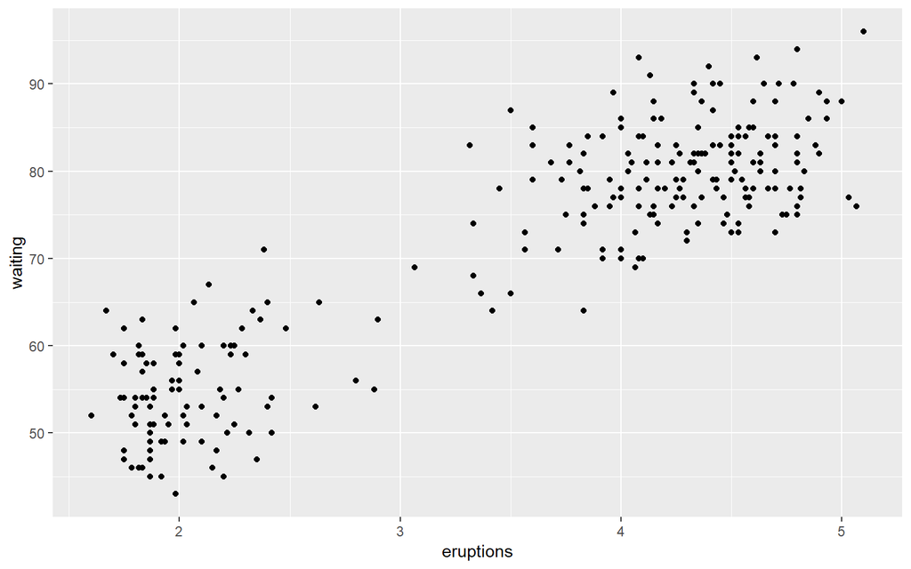

```r
ggplot(data = faithful) +
  geom_point(mapping = aes(x = eruptions, y = waiting))
```

패턴은 공분산을 나타내기 때문에 데이터사이언티스트에게 가장 유용한 도구중 하나를 제공한다.분산을 불확실성에 의해 만들어 졌다고 생각한다면, 공분산은 그것을 감소시켜 줄 것이다. 두 변수가 하나의 변수에 따라 달라진다면 하나의 변수를 더 좋은 예측을 위해 사용할 수 있다. 만약 공분산이 인과관계에 의한 것이라면, 두번째 변수를 통제함으로써 하나의 변수를 이용할 수 있다.

모델은 데이터의 패턴을 추출하는 도구이다. 예를 들어, 다이몬드 데이터를 고려해보자. cut과 price의 관계를 이해하기에 어려운데, 왜냐하면 cut과 carat 그리고 carat과 price가 강하게 연관되어 있기 때문이다. 모델을 이용하여 price와 carat의 강한 관계를 제거할 수 있어서 남아있는 미묘함을 탐색할 수 있다. 잔차는 우리에게 다이아의 가격에 대한 시점을 제공하고, 케럿의 효과를 제거한다.

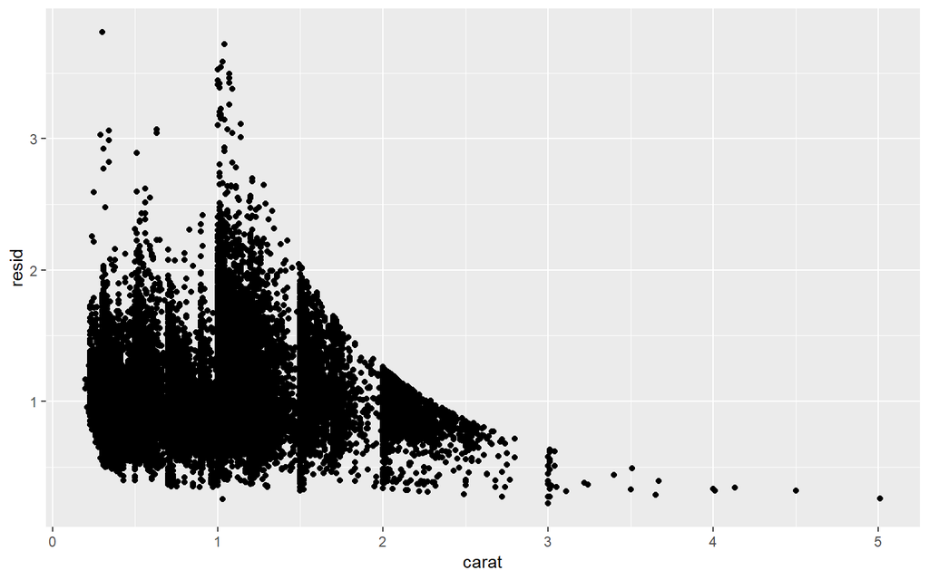

```r
library(modelr)

mod <- lm(log(price) ~ log(carat), data = diamonds)

diamonds2 <- diamonds %>%
  add_residuals(mod) %>%  # resid열 추가
  mutate(resid = exp(resid)) # 해석을 위해 역변환

ggplot(diamonds2) +
  geom_point(aes(carat, resid))
```

carat과 price의 강한 관계를 제거 했을 때, cut과 price의 기대한 관계를 볼 수 있다. 상대적 size, 좋은 품질의 다이아가 더 비싸다.

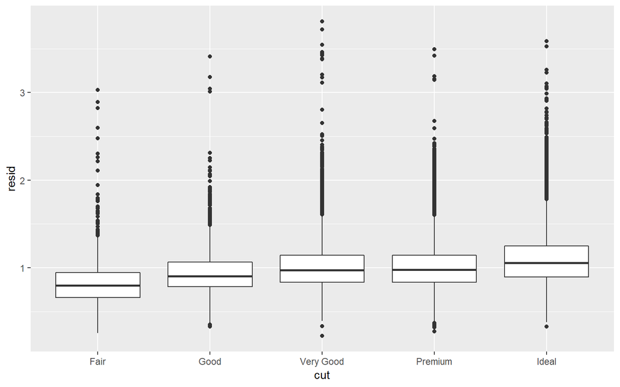

```r
ggplot(diamonds2) +
  geom_boxplot(aes(cut, resid))
```

# 2 Summary

- 범주에 따라 종속변수의 변화는 effect로 판단 할 수 있다.
- 데이터가 1000을 넘어가면 `geom_lv(aes(fill = ..LV..))`를 고려해보자.
- 분포의 모양 비교는 `facet_wrat(ncol = 1, scales = "free_y")`, y값 비교는 `geom_freqpoly(stat(density))`
- `geom_jitter()`대신에 `ggbeeswarm::geom_quasirandom()`
- 두 범주는 히트맵을 통하여 파악하자.
- 항상 플랏을 그리고난후, 의미 있는 양으로 정렬을 하고 결측치를 제거하며, 더 좋은 색상을 사용하자.
- `ungroup()`을 습관화하자.
- 오버플랏 해결 방안: 투명도, bin, 그리고 연속형 변수를 범주형으로 cut해서 boxplot을 그리는 방법이 있는데 각 박스플랏의 점의 수가 다르므로 `cut_number()`을 사용할 수도 있다.
- 특정 변수의 분포를 이 변수와 상관관계가 큰 변수로 구간을 몇개 나눠서 분포의 모양을 보면 흥미로운 패턴을 볼 수도 있다. `cut_width()`와 `cut_number()`을 둘 다 사용해보자.
- bin plot은 이상치가 잘 보이지 않음에 유의하자.